# TP2 – Régressions Linéaires

- Montrer tout le code
- Cacher tout le code
- Voir les sources

Auteur·rice

HAMLIL Mohamed

Date de publication

2025

# Introduction

Dans ce TP, on étudie la relation entre la **tension artérielle** et l’**âge** des individus. Les données ont été simulées à partir de *BOUYER et al. (1995) Épidémiologie. Principes et méthodes quantitatives, Les éditions INSERM*.

**Objectif :** Déterminer si l’âge a une influence sur la tension artérielle et éventuellement **prédire** la tension en fonction de l’âge.

# 1. Régression Linéaire Simple

## 1.1 Statistiques descriptives

**(i) Identification des variables :**

- **Variable explicative** (indépendante) : l’âge ($x$)
- **Variable expliquée** (dépendante) : la tension artérielle ($y$)

**(ii) Importation des données :**

```r
data = read.csv("tension.csv", header = TRUE, sep = ";", dec = ",")
head(data)
x = data$age
y = data$tension
head(x)
head(y)
```

A data.frame: 6 × 2

|  | age <int> | tension <dbl> |
| --- | --- | --- |
| 1 | 44 | 136.1 |
| 2 | 44 | 132.0 |
| 3 | 55 | 148.8 |
| 4 | 44 | 127.5 |
| 5 | 41 | 130.2 |
| 6 | 51 | 136.7 |

1. 44

2. 44

3. 55

4. 44

5. 41

6. 51

1. 136.1

2. 132

3. 148.8

4. 127.5

5. 130.2

6. 136.7

**(iii) Nuage de points :**

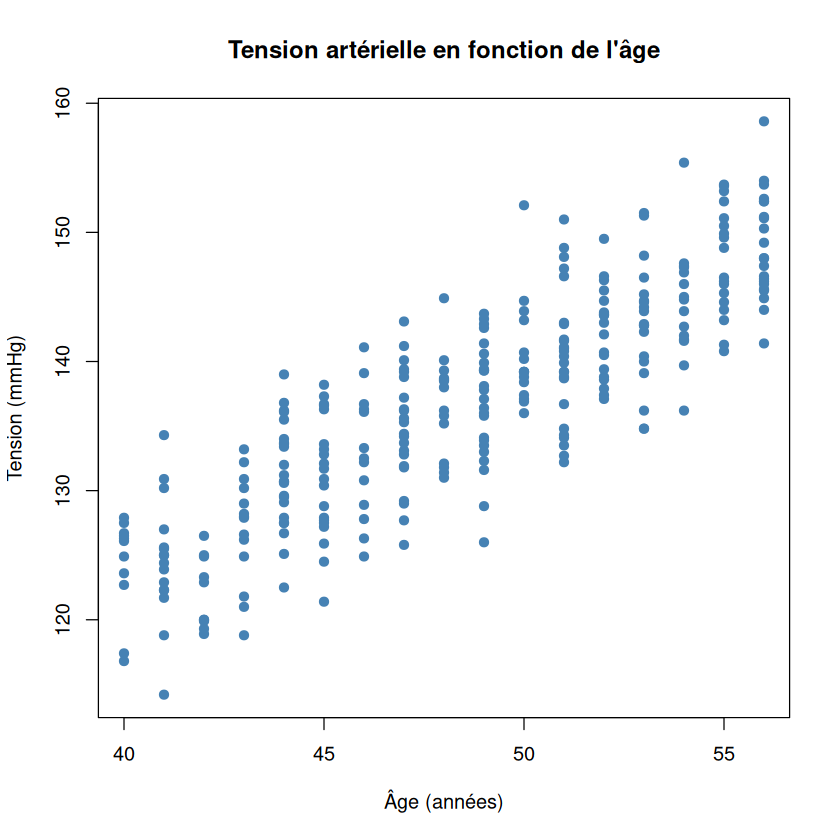

```r
plot(x, y,
     main = "Tension artérielle en fonction de l'âge",
     xlab = "Âge (années)", ylab = "Tension (mmHg)",
     pch = 19, col = "steelblue")
```

**Commentaire :** Le nuage est relativement rectiligne. La régression linéaire a du sens et donnera une tendance moyennement précise de $y$ en fonction de $x$.

**(iv) Coefficient de corrélation linéaire :**

```r
r = cor(x, y)
cat("Coefficient de corrélation r =", round(r, 4))
```

```
Coefficient de corrélation r = 0.8638
```

Sa valeur confirme la tendance linéaire observée graphiquement.

**(v) Calcul des coefficients de la droite de régression :**

On cherche $y = \hat{\beta}_1 x + \hat{\beta}_0$ par la méthode des **moindres carrés** :

$$\hat{\beta}_1 = \frac{\text{Cov}(x, y)}{\text{Var}(x)}, \quad \hat{\beta}_0 = \bar{y} - \hat{\beta}_1 \bar{x}$$

```r
beta1 = cov(x, y) / var(x)
beta0 = mean(y) - beta1 * mean(x)
cat("beta1 =", round(beta1, 4), "\nbeta0 =", round(beta0, 4))
```

```
beta1 = 1.5994
beta0 = 59.127
```

**(vi) Vérification avec `lm` :**

```r
lm(y ~ x)
```

```
Call:
lm(formula = y ~ x)

Coefficients:
(Intercept)            x
     59.127        1.599
```

**(vii) Tracé de la droite de régression :**

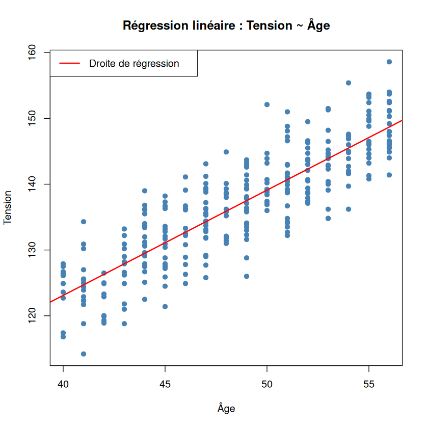

```r
plot(x, y,
     main = "Régression linéaire : Tension ~ Âge",
     xlab = "Âge", ylab = "Tension",
     pch = 19, col = "steelblue")
abline(beta0, beta1, col = "red", lwd = 2)
legend("topleft", legend = "Droite de régression", col = "red", lwd = 2)
```

## 1.2 Résidus

Les résidus (erreurs) mesurent l’écart entre les valeurs observées et les valeurs prédites par le modèle.

**(i) Calcul à la main :**

```r
yajust = beta1 * x + beta0
erreurs = y - yajust
```

**(ii) Avec la fonction `lm` :**

```r
model = lm(y ~ x)
beta0 = model$coefficients[1]
beta1 = model$coefficients[2]
yajustes = model$fitted.values
erreurs = model$residuals
```

**(iii) Résidus en fonction des valeurs ajustées :**

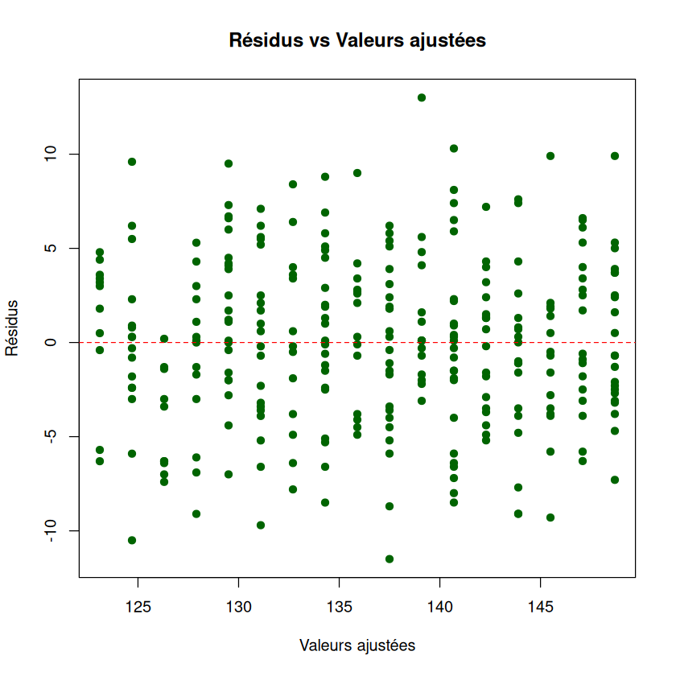

```r
plot(yajustes, erreurs,
     main = "Résidus vs Valeurs ajustées",
     xlab = "Valeurs ajustées", ylab = "Résidus",
     pch = 19, col = "darkgreen")
abline(h = 0, col = "red", lty = 2)
```

**(iv) Structure des résidus ?**

Il ne semble pas y avoir de structure particulière des erreurs. C’est ce qu’on attend : dans une régression linéaire, les erreurs doivent être distribuées selon $\mathcal{N}(0, \sigma)$ et être indépendantes de la variable explicative.

**(v) Densité des résidus :**

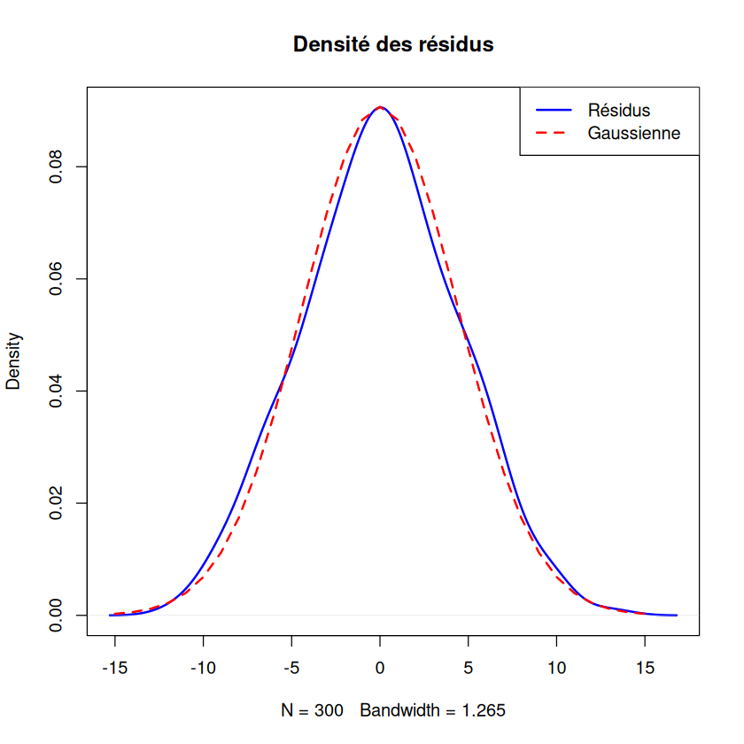

```r
plot(density(erreurs),
     main = "Densité des résidus",
     col = "blue", lwd = 2)

# Comparaison avec la densité gaussienne
discr = -15:15
norm = dnorm(discr, 0, sqrt(var(erreurs)))
lines(discr, norm, col = "red", lwd = 2, lty = 2)
legend("topright", legend = c("Résidus", "Gaussienne"),
       col = c("blue", "red"), lwd = 2, lty = c(1, 2))
```

**(vi) QQ-plot et test de Shapiro-Wilk :**

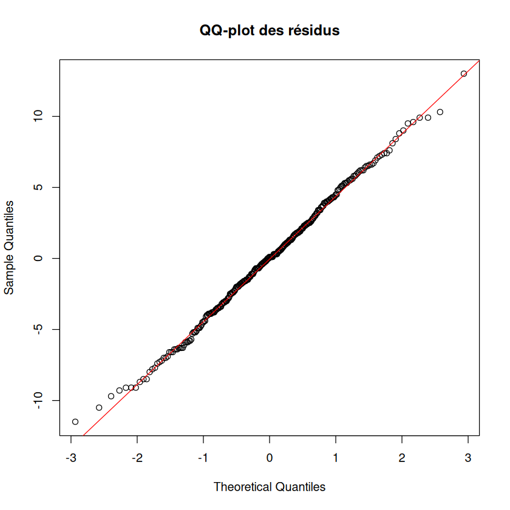

```r
qqnorm(erreurs, main = "QQ-plot des résidus")
qqline(erreurs, col = "red")
```

```r
shapiro.test(erreurs)
```

```
    Shapiro-Wilk normality test

data:  erreurs
W = 0.99749, p-value = 0.9296
```

**Conclusion :** Avec une p-value supérieure à 5%, on **ne rejette pas** la normalité des résidus.

## 1.3 Somme des carrés

Rappel des trois sommes fondamentales :

- **SCE** (Somme des Carrés des Erreurs) : $\sum (y_i - \hat{y}_i)^2$
- **SCT** (Somme des Carrés Totale) : $\sum (y_i - \bar{y})^2$
- **SCM** (Somme des Carrés du Modèle) : $\sum (\hat{y}_i - \bar{y})^2$

**(i) Calcul :**

```r
SCE = sum(erreurs^2)
SCT = sum((y - mean(y))^2)
SCM = sum((yajustes - mean(y))^2)
cat("SCE =", round(SCE, 2), "\nSCT =", round(SCT, 2), "\nSCM =", round(SCM, 2))
```

```
SCE = 5785.65
SCT = 22798.4
SCM = 17012.76
```

**(ii) Vérification de la décomposition :**

$$SCT = SCM + SCE$$

```r
cat("SCM + SCE =", round(SCM + SCE, 2), "\nSCT =", round(SCT, 2))
```

```
SCM + SCE = 22798.4
SCT = 22798.4
```

**(iii) Coefficient de détermination $R^2$ :**

```r
R2 = SCM / SCT
cat("R² =", round(R2, 4))
cat("\ncor(x,y)² =", round(cor(x, y)^2, 4))
```

```
R² = 0.7462
cor(x,y)² = 0.7462
```

On vérifie que $R^2 = r^2$ (carré du coefficient de corrélation).

## 1.4 Distribution de $\hat{\beta}_1$

Pour comprendre la variabilité de l’estimateur $\hat{\beta}_1$, on simule 100 échantillons du même modèle.

**(i) Simulation de 100 échantillons :**

```r
set.seed(42)
age_sim = sample(40:56, replace = TRUE, 30000)
simx = matrix(age_sim, nrow = 100)

err_sim = rnorm(30000, 0, sqrt(SCE / (length(x) - 2)))
simerr = matrix(err_sim, nrow = 100)

simy = beta1 * simx + beta0 + simerr
```

**(ii) Calcul de $\hat{\beta}_1$ pour chaque échantillon :**

```r
simbeta = numeric(100)
for (i in 1:100) {
  simbeta[i] = cov(simx[i, ], simy[i, ]) / var(simx[i, ])
}
```

**(iii) Comparaison avec la loi de Student :**

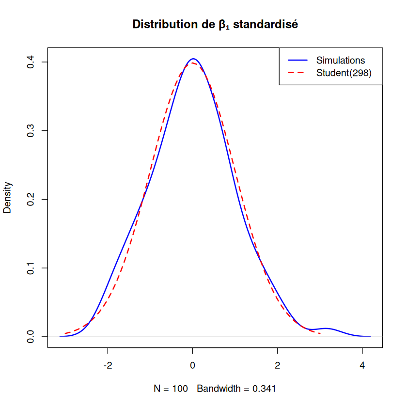

```r
plot(density((simbeta - mean(simbeta)) / sqrt(var(simbeta))),
     main = "Distribution de β̂₁ standardisé",
     col = "blue", lwd = 2)
discr = seq(-3, 3, 0.1)
lines(discr, dt(discr, 298), col = "red", lwd = 2, lty = 2)
legend("topright", legend = c("Simulations", "Student(298)"),
       col = c("blue", "red"), lwd = 2, lty = c(1, 2))
```

## 1.5 Intervalle de confiance de $\beta_1$

L’intervalle de confiance à 95% pour $\beta_1$ est :

$$\hat{\beta}_1 + t_{n-2; 0.025} \cdot \hat{\sigma}_{\beta_1} \leq \beta_1 \leq \hat{\beta}_1 - t_{n-2; 0.025} \cdot \hat{\sigma}_{\beta_1}$$

```r
sbeta1 = sqrt(SCE / (398 * sum((x - mean(x))^2)))
binf = beta1 + qt(0.025, 298) * sbeta1
bsup = beta1 + qt(0.975, 298) * sbeta1
cat("Intervalle de confiance à 95% pour β₁ : [", round(binf, 4), ";", round(bsup, 4), "]")
```

[output not shown]

Valeurs de `simbeta` en dehors de l’intervalle :

```r
hors_ic = simbeta[simbeta > bsup | simbeta < binf]
cat("Nombre de valeurs hors IC :", length(hors_ic))
cat("\nValeurs :", round(hors_ic, 4))
```

```
Nombre de valeurs hors IC : 7
Valeurs : 1.707 1.4998 1.7587 1.4931 1.7066 1.5028 1.5061
```

# 2. Tests de la Régression Linéaire

## 2.1 Test de Fisher et ANOVA

Le coefficient de détermination $R^2$ est inférieur à 0.8, mais cela ne signifie pas que $X$ n’explique pas $Y$. On teste l’hypothèse $H_0 : \beta_1 = 0$ (le modèle n’apporte rien).

**(i) Tableau d’ANOVA :**

```r
anova(lm(y ~ x))
```

A anova: 2 × 5

|  | Df <int> | Sum Sq <dbl> | Mean Sq <dbl> | F value <dbl> | Pr(>F) <dbl> |
| --- | --- | --- | --- | --- | --- |
| x | 1 | 17012.758 | 17012.75752 | 876.2722 | 9.777196e-91 |
| Residuals | 298 | 5785.647 | 19.41492 | NA | NA |

Ou de manière équivalente :

```r
summary(aov(y ~ x))
```

```
             Df Sum Sq Mean Sq F value Pr(>F)
x             1  17013   17013   876.3 <2e-16 ***
Residuals   298   5786      19
---
Signif. codes:  0 ‘***’ 0.001 ‘**’ 0.01 ‘*’ 0.05 ‘.’ 0.1 ‘ ’ 1
```

**Interprétation :** La p-value (`Pr(>F)`) est proche de zéro → on **rejette** la nullité de $\beta_1$. La variable $X$ explique $Y$ de manière **significative**.

**(ii) Retrouver SCE et SCM :** on les reconnaît dans les colonnes `Sum Sq` du tableau.

**(iii) Statistique de Fisher :**

$$F = \frac{SCM}{SCE / (n-2)} = \frac{298 \times SCM}{SCE}$$

```r
F_stat = 298 * SCM / SCE
cat("F observé =", round(F_stat, 2))
```

```
F observé = 876.27
```

**(iv) Comparaison au seuil 5% :**

```r
cat("Quantile F(0.95, 1, 298) =", round(qf(0.95, 1, 298), 4))
```

```
Quantile F(0.95, 1, 298) = 3.8729
```

**(v) p-value :**

```r
cat("p-value =", 1 - pf(F_stat, 1, 298))
```

```
p-value = 0
```

**(vi) Résumé complet du modèle :**

```r
summary(lm(y ~ x))
```

```
Call:
lm(formula = y ~ x)

Residuals:
     Min       1Q   Median       3Q      Max
-11.4981  -3.0256   0.0987   2.9247  13.0025

Coefficients:
            Estimate Std. Error t value Pr(>|t|)
(Intercept) 59.12702    2.63496   22.44   <2e-16 ***
x            1.59941    0.05403   29.60   <2e-16 ***
---
Signif. codes:  0 ‘***’ 0.001 ‘**’ 0.01 ‘*’ 0.05 ‘.’ 0.1 ‘ ’ 1

Residual standard error: 4.406 on 298 degrees of freedom
Multiple R-squared:  0.7462,    Adjusted R-squared:  0.7454
F-statistic: 876.3 on 1 and 298 DF,  p-value: < 2.2e-16
```

On observe que la statistique du test de Student au carré est égale à la statistique de Fisher. C’est normal : les deux tests sont équivalents ici !

# 3. Prévision

On veut prédire la tension artérielle d’un homme de **50 ans** avec un **intervalle de confiance à 95%**.

La formule de l’intervalle de prévision est :

$$\hat{Y}_0 \pm t_{n-2; 0.025} \sqrt{s_\epsilon^2 \left(1 + \frac{1}{n} + \frac{(X_0 - \bar{X})^2}{\sum (X_i - \bar{X})^2}\right)}$$

```r
se2 = SCE / 298
Y0 = beta1 * 50 + beta0
cat("Prévision de la tension pour un homme de 50 ans : Ŷ₀ =", round(Y0, 2), "mmHg")
```

```
Prévision de la tension pour un homme de 50 ans : Ŷ₀ = 139.1 mmHg
```

```r
bsup_prev = Y0 + qt(0.975, 298) * sqrt(se2 * (1 + 1/300 + (50 - mean(x))^2 / sum((x - mean(x))^2)))
binf_prev = Y0 - qt(0.975, 298) * sqrt(se2 * (1 + 1/300 + (50 - mean(x))^2 / sum((x - mean(x))^2)))
cat("Intervalle de prévision : [", round(binf_prev, 2), ";", round(bsup_prev, 2), "]")
```

```
Intervalle de prévision : [ 130.41 ; 147.78 ]
```

### Visualisation avec intervalle de confiance

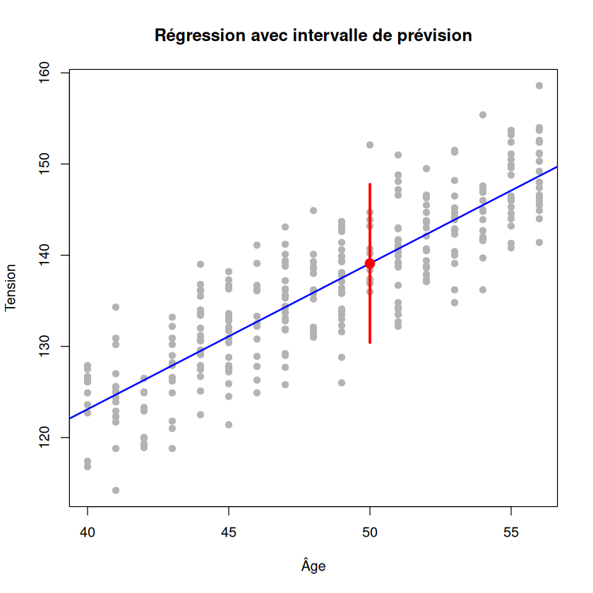

```r
plot(x, y,
     main = "Régression avec intervalle de prévision",
     xlab = "Âge", ylab = "Tension",
     pch = 19, col = "gray70")
abline(beta0, beta1, col = "blue", lwd = 2)
lines(c(50, 50), c(binf_prev, bsup_prev), col = "red", lwd = 3)
points(50, Y0, pch = 19, col = "red", cex = 1.5)
```

### Bande de confiance complète

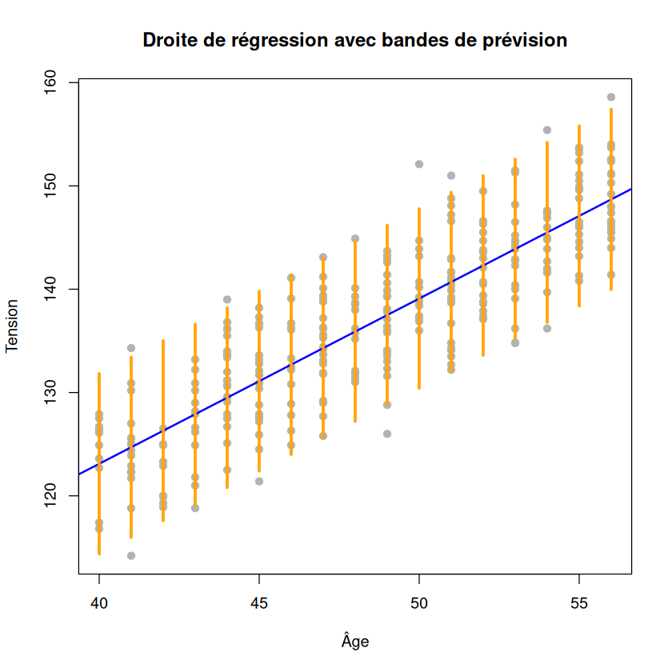

```r
plot(x, y,
     main = "Droite de régression avec bandes de prévision",
     xlab = "Âge", ylab = "Tension",
     pch = 19, col = "gray70")
abline(beta0, beta1, col = "blue", lwd = 2)

discr = 40:56
predicted = beta1 * discr + beta0
bsup_band = predicted + qt(0.975, 298) * sqrt(se2 * (1 + 1/300 + (discr - mean(x))^2 / sum((x - mean(x))^2)))
binf_band = predicted - qt(0.975, 298) * sqrt(se2 * (1 + 1/300 + (discr - mean(x))^2 / sum((x - mean(x))^2)))

for (i in 1:length(discr)) {
  lines(c(discr[i], discr[i]), c(binf_band[i], bsup_band[i]), lwd = 3, col = "orange")
}
```

# 4. Régression Linéaire Multiple

## 4.1 Contexte

Pour mesurer les performances auditives d’un individu, on le soumet à un signal sonore de fréquence donnée. On mesure le **seuil** (en décibel) à partir duquel le signal est perçu. Un seuil élevé indique un trouble de l’audition.

Les données contiennent les mesures pour 4 fréquences (500Hz, 1000Hz, 2000Hz, 4000Hz) et une auto-évaluation `globale` pour 1000 personnes de plus de 39 ans.

**L’enjeu :** Prédire `globale` par `A5`, `A10`, `A20`, `A40`.

## 4.2 Import des données

```r
audition = read.csv2("audition2.csv")
head(audition)
A5 = audition$A5
A10 = audition$A10
A20 = audition$A20
A40 = audition$A40
globale = audition$globale
```

A data.frame: 6 × 5

|  | A5 <dbl> | A10 <dbl> | A20 <dbl> | A40 <dbl> | globale <dbl> |
| --- | --- | --- | --- | --- | --- |
| 1 | 0.01285502 | 0.9663823 | 0.87514354 | -0.9128070 | 5.142168 |
| 2 | 0.12055133 | -0.3726908 | 1.11712729 | 1.4278677 | 5.615904 |
| 3 | -0.11320012 | 0.1210239 | 0.03302541 | 0.8079420 | 4.522749 |
| 4 | 2.05565754 | 2.0908744 | 0.36550190 | -1.0883933 | 6.654767 |
| 5 | 1.44488695 | 0.9841622 | 0.45854632 | -0.2759891 | 6.623146 |
| 6 | 0.60567511 | 1.0954039 | 1.95068690 | 2.1028709 | 7.228318 |

## 4.3 Coefficients de la régression

```r
lm(globale ~ A5 + A10 + A20 + A40)
```

```
Call:
lm(formula = globale ~ A5 + A10 + A20 + A40)

Coefficients:
(Intercept)           A5          A10          A20          A40
     4.1423       0.7082       0.8602       0.6355       0.5106
```

L’équation de la régression est :

$$\text{globale} = 4.14 + 0.71 \times A5 + 0.86 \times A10 + 0.64 \times A20 + 0.51 \times A40$$

On voit que le niveau d’audition évalué par le sujet augmente quand chaque seuil augmente, avec sensiblement la même importance.

## 4.4 Tests statistiques

```r
summary(lm(globale ~ A5 + A10 + A20 + A40))
```

```
Call:
lm(formula = globale ~ A5 + A10 + A20 + A40)

Residuals:
     Min       1Q   Median       3Q      Max
-1.63918 -0.19985  0.04163  0.27016  0.72287

Coefficients:
            Estimate Std. Error t value Pr(>|t|)
(Intercept)  4.14226    0.01274  325.10   <2e-16 ***
A5           0.70820    0.01808   39.17   <2e-16 ***
A10          0.86024    0.01948   44.17   <2e-16 ***
A20          0.63553    0.01439   44.17   <2e-16 ***
A40          0.51059    0.01333   38.30   <2e-16 ***
---
Signif. codes:  0 ‘***’ 0.001 ‘**’ 0.01 ‘*’ 0.05 ‘.’ 0.1 ‘ ’ 1

Residual standard error: 0.3613 on 995 degrees of freedom
Multiple R-squared:  0.9653,    Adjusted R-squared:  0.9651
F-statistic:  6911 on 4 and 995 DF,  p-value: < 2.2e-16
```

**Interprétation :**

- Le **test de Fisher** (dernière ligne) montre que les variables explicatives ont, dans leur globalité, un effet **significatif** sur `globale`.
- Tous les **tests de Student** sont significatifs → chaque variable contribue significativement.
- Le coefficient $R^2 \approx 0.97$ → 97% de la variance de `globale` est expliquée par le modèle linéaire.
- On peut penser que le patient a une évaluation **lucide** de son état d’audition.

# Résumé

| Concept | Description | Fonction R |
| --- | --- | --- |
| Régression simple | $y = \beta_1 x + \beta_0$ | `lm(y ~ x)` |
| Résidus | Écarts entre observé et prédit | `model$residuals` |
| SCE, SCT, SCM | Décomposition de la variance | Calcul manuel |
| $R^2$ | Part de variance expliquée | `SCM/SCT` ou `summary()` |
| Test de Fisher | $\beta_1 = 0$ ? | `anova(lm())` |
| Prévision | Prédiction avec IC | Formule manuelle |
| Régression multiple | Plusieurs variables explicatives | `lm(y ~ x1 + x2 + ...)` |